# Organizando um projeto de análise de dados com RStudio

Adriana Picoral

12 de novembro de 2020

Esse material foi desenvolvido para o primeiro meetup (online) da R-Ladies de Ribeirão Preto (@RLadiesRP). As instruções nesse documento são baseadas, em parte, nas postagens de [Jeff Leek chamada “Organizing a data analysis”](https://jhuadvdatasci.substack.com/p/jhu-ads-2020-week-3-organizing-a) e de [Jenny Bryan chamada “Project-oriented workflow”](https://www.tidyverse.org/blog/2017/12/workflow-vs-script/).

Os objetivos desse workshop são:

1. Identificar as vantagens de um projeto be organizado
2. Desenvolver um estilo de programação, including nomeação consistente (i.e., não variável) de arquivos e pastas
3. Diferenciar entre processo e produto da análise de dados

# 1 Instalação de R e RStudio

Apesar de R ter seu próprio ambiente de desenvolvimento integrado (IDE - integrated development environment), RStudio é amplamente adotado como a IDE preferida de muitos cientistas de dados. Os motivos para tanto são muitos. Em geral, o propósito de uma IDE é facilitar o processo de escrever código oferencendo um ambiente que integra um editor de texto (onde o código é escrito e editado), o console (onde o código é rodado), e outras ferramentas de supporte.

**Por que usar RStudio?**

O IDE que o RStudio oferece facilita o processo de análise de dados, porque contain as seguintes features:

- RStudio é gratuíto e *open source*.
- O editor do RStudio é completamente integrado no IDE, com auto preenchimento (tab-completion)
- RStudio é igual não importa qual plataforma você usa (Windows, Linux, Mac, Cloud)
- É possivel criar *Projects* com RStudio que facilitam a organização de projetos de análise de dados

**Instruções de instalação do R e do RStudio:**

1. Baixe e instale R do site https://cran.r-project.org (Se você usa Windows, primeiro [determine se você tem Windows de 32 ou 64 bits](https://www.computerhope.com/issues/ch001121.htm#:~:text=Press%20and%20hold%20the%20Windows,running%20the%2064%2Dbit%20version.))
2. Baixe e instale RStudio do site https://rstudio.com/products/rstudio/download/#download

Uma pergunta comum é com que frequência se deve atualizar o R e o RStudio. É importante ter sempre a última versão de R, RStudio, e seus pacotes de R, para garantir que se código não tenha nenhum erros.

# 2 Verificando versões

1. Abra seu RStudio
2. No console, entre `sessionInfo()` para verificar sua versão de R e seu sistema operacional
3. No menu do seu RStudio, click em `Tools/Ferramentas` e escolha `Check for Packages Updates...` pra verificar se existe alguma atualização disponível pra pacotes que você tem instalado no seu computador

# 3 Por que organização é importante?

O principal motivo pra organizar um projeto de análise de dados é reprodutibilidade. Já acontenceu de você ter que abrir um script de R para re-rodar uma análise e você ter que passar um tempo tentando entender o que você mesmo fez seis meses atrás? Pois é, seja gentil com você mesmo, e organize seus projetos pra que no futuro você possa recriar seus resultados com sucesso.

Além disso, se todos os colaboradores de um projeto tem as mesmas expectativas de organização, a colaboração se torna um processo mais fácil e sua análise fica mais robusta (menores chances de erros). Nos EUA, pesquisadores estão cada vez mais disponibilizando seus códigos e dados de suas análises para ajudar com estudos de replicação e transparência em geral. Em alguns anos, será esperado esse tipo de transparência na maioria de publicações científicas sérias.

# 4 Crie um Projeto no RStudio

# 5 Prática – eBird Brazilian Birdwatching Observations

Vamos usar dados de [eBird Brazilian Birdwatching Observations](https://www.kaggle.com/danlessa/ebird-brazilian-observations) retirados do [Kgggle](https://www.kaggle.com/).

Crie uma pasta chamada `raw_data` dentro de seu Projeto. Mova e renomeie o arquivo que você baixou do Kaggle pra essa pasta.

Crie um novo R script com o nome de `01-data_wrangling.R`.

## 5.1 Work Environment

Certifique-se de que seu projeto consegue “ver” o arquivo de dados.

```r
# check work environment
getwd()
```

```
## [1] "/Users/adriana/Desktop/workshops/organizando_projeto"
```

```r
# list contents of current folder
dir()
```

```
## [1] "figures"                   "index.html"
## [3] "index.Rmd"                 "organizando_projeto.Rproj"
## [5] "processed_data"            "raw_data"
## [7] "test.pdf"                  "test.Rmd"
```

```r
list.files()
```

```
## [1] "figures"                   "index.html"
## [3] "index.Rmd"                 "organizando_projeto.Rproj"
## [5] "processed_data"            "raw_data"
## [7] "test.pdf"                  "test.Rmd"
```

```r
# list contents of raw_data folder
dir("raw_data")
```

```
## [1] "ebird_brazil.csv"
```

```r
list.files("raw_data")
```

```
## [1] "ebird_brazil.csv"
```

## 5.2 Instalação e Carregamento de Pacotes

Antes de começarmos, precisamos dos seguintes pacotes de R.

```r
install.packages("tidyverse")
install.packages("janitor")
install.packages("skimr")
```

Depois de instalar/atualizar os pacotes `tidyverse`, é necessário carregar esses pacotes com a função `library()`.

```r
# load libraries
library(tidyverse)
library(janitor)
library(skimr)
```

## 5.3 Data Wrangling em R (01-data_wrangling.R)

Existem muitas funções que lêem dados no R, minha preferida é a família `read_csv()`, `read_tsv()`, etc.

```r
# read data in
bird_data <- read_tsv("raw_data/ebird_brazil.csv")
```

Sempre inspecione seus dados.

```r
# inspect data
glimpse(bird_data)
```

```
## Rows: 3,587,953
## Columns: 50
## $ gbifID                           <dbl> 181559517, 181560025, 181560303, 181…
## $ datasetKey                       <chr> "4fa7b334-ce0d-4e88-aaae-2e0c138d049…
## $ occurrenceID                     <chr> "URN:catalog:CLO:EBIRD:OBS54999031",…
## $ kingdom                          <chr> "Animalia", "Animalia", "Animalia", …
## $ phylum                           <chr> "Chordata", "Chordata", "Chordata", …
## $ class                            <chr> "Aves", "Aves", "Aves", "Aves", "Ave…
## $ order                            <chr> "Passeriformes", "Passeriformes", "P…
## $ family                           <chr> "Icteridae", "Icteridae", "Icteridae…
## $ genus                            <chr> "Molothrus", "Molothrus", "Molothrus…
## $ species                          <chr> "Molothrus bonariensis", "Molothrus …
## $ infraspecificEpithet             <lgl> NA, NA, NA, NA, NA, NA, NA, NA, NA, …
## $ taxonRank                        <chr> "SPECIES", "SPECIES", "SPECIES", "SP…
## $ scientificName                   <chr> "Molothrus bonariensis (Gmelin, 1789…
```

[output cut: 37 more lines]

Os nomes das colunas estão em camelCase, a minha preferência pessoal é snake_case. A função `clean_names()`, cujo default é “snake”.

```r
# standardize column names to snake_case
bird_data <- bird_data %>%
  clean_names()
```

Sempre cheque seus dados pra verificar se as mudanças tiveram efeito.

```r
# inspect data
glimpse(bird_data)
```

```
## Rows: 3,587,953
## Columns: 50
## $ gbif_id                             <dbl> 181559517, 181560025, 181560303, …
## $ dataset_key                         <chr> "4fa7b334-ce0d-4e88-aaae-2e0c138d…
## $ occurrence_id                       <chr> "URN:catalog:CLO:EBIRD:OBS5499903…
## $ kingdom                             <chr> "Animalia", "Animalia", "Animalia…
## $ phylum                              <chr> "Chordata", "Chordata", "Chordata…
## $ class                               <chr> "Aves", "Aves", "Aves", "Aves", "…
## $ order                               <chr> "Passeriformes", "Passeriformes",…
## $ family                              <chr> "Icteridae", "Icteridae", "Icteri…
## $ genus                               <chr> "Molothrus", "Molothrus", "Moloth…
## $ species                             <chr> "Molothrus bonariensis", "Molothr…
## $ infraspecific_epithet               <lgl> NA, NA, NA, NA, NA, NA, NA, NA, N…
## $ taxon_rank                          <chr> "SPECIES", "SPECIES", "SPECIES", …
## $ scientific_name                     <chr> "Molothrus bonariensis (Gmelin, 1…
```

[output cut: 37 more lines]

```r
skim(bird_data)
```

Data summary

| Name | bird_data |
| --- | --- |
| Number of rows | 3587953 |
| Number of columns | 50 |
| _______________________ |  |
| Column type frequency: |  |
| character | 23 |
| logical | 16 |
| numeric | 9 |
| POSIXct | 2 |
| ________________________ |  |
| Group variables | None |

**Variable type: character**

| skim_variable | n_missing | complete_rate | min | max | empty | n_unique | whitespace |
| --- | --- | --- | --- | --- | --- | --- | --- |
| dataset_key | 0 | 1.00 | 36 | 36 | 0 | 1 | 0 |
| occurrence_id | 0 | 1.00 | 33 | 43 | 0 | 3587953 | 0 |
| kingdom | 0 | 1.00 | 8 | 8 | 0 | 1 | 0 |
| phylum | 0 | 1.00 | 8 | 8 | 0 | 1 | 0 |
| class | 0 | 1.00 | 4 | 4 | 0 | 1 | 0 |
| order | 0 | 1.00 | 10 | 19 | 0 | 29 | 0 |
| family | 0 | 1.00 | 7 | 17 | 0 | 87 | 0 |
| genus | 170 | 1.00 | 3 | 16 | 0 | 661 | 0 |
| species | 16621 | 1.00 | 9 | 33 | 0 | 1661 | 0 |
| taxon_rank | 0 | 1.00 | 5 | 7 | 0 | 3 | 0 |
| scientific_name | 0 | 1.00 | 11 | 83 | 0 | 1682 | 0 |
| verbatim_scientific_name | 0 | 1.00 | 9 | 33 | 0 | 1687 | 0 |
| country_code | 0 | 1.00 | 2 | 2 | 0 | 1 | 0 |
| locality | 0 | 1.00 | 1 | 58590386 | 0 | 35367 | 0 |
| state_province | 0 | 1.00 | 4 | 19 | 0 | 27 | 0 |
| publishing_org_key | 0 | 1.00 | 36 | 36 | 0 | 1 | 0 |
| basis_of_record | 0 | 1.00 | 17 | 17 | 0 | 1 | 0 |
| institution_code | 0 | 1.00 | 3 | 3 | 0 | 1 | 0 |
| collection_code | 0 | 1.00 | 5 | 14 | 0 | 28 | 0 |
| catalog_number | 0 | 1.00 | 11 | 12 | 0 | 3587953 | 0 |
| license | 0 | 1.00 | 7 | 7 | 0 | 1 | 0 |
| recorded_by | 0 | 1.00 | 8 | 11 | 0 | 4380 | 0 |
| issue | 759244 | 0.79 | 17 | 41 | 0 | 5 | 0 |

**Variable type: logical**

| skim_variable | n_missing | complete_rate | mean | count |
| --- | --- | --- | --- | --- |
| infraspecific_epithet | 3587953 | 0 | NaN | : |
| verbatim_scientific_name_authorship | 3587953 | 0 | NaN | : |
| occurrence_status | 3587953 | 0 | NaN | : |
| coordinate_uncertainty_in_meters | 3587953 | 0 | NaN | : |
| coordinate_precision | 3587953 | 0 | NaN | : |
| elevation | 3587953 | 0 | NaN | : |
| elevation_accuracy | 3587953 | 0 | NaN | : |
| depth | 3587953 | 0 | NaN | : |
| depth_accuracy | 3587953 | 0 | NaN | : |
| record_number | 3587953 | 0 | NaN | : |
| identified_by | 3587953 | 0 | NaN | : |
| date_identified | 3587953 | 0 | NaN | : |
| rights_holder | 3587953 | 0 | NaN | : |
| type_status | 3587953 | 0 | NaN | : |
| establishment_means | 3587953 | 0 | NaN | : |
| media_type | 3587953 | 0 | NaN | : |

**Variable type: numeric**

| skim_variable | n_missing | complete_rate | mean | sd | p0 | p25 | p50 | p75 | p100 | hist |
| --- | --- | --- | --- | --- | --- | --- | --- | --- | --- | --- |
| gbif_id | 0 | 1.00 | 1813228035.28 | 431160839.15 | 145802518.00 | 1404613188.00 | 2056711849.00 | 2153281655.00 | 2234213761.00 | ▁▁▂▃▇ |
| individual_count | 807329 | 0.77 | 4.18 | 84.33 | 1.00 | 1.00 | 2.00 | 3.00 | 100000.00 | ▇▁▁▁▁ |
| decimal_latitude | 0 | 1.00 | -17.90 | 7.83 | -35.01 | -23.44 | -20.91 | -12.14 | 4.50 | ▁▇▃▂▁ |
| decimal_longitude | 0 | 1.00 | -49.35 | 6.27 | -73.67 | -55.91 | -48.08 | -45.13 | -30.02 | ▁▃▇▇▁ |
| day | 0 | 1.00 | 15.55 | 8.62 | 1.00 | 8.00 | 15.00 | 23.00 | 31.00 | ▇▇▇▇▆ |
| month | 0 | 1.00 | 7.35 | 3.08 | 1.00 | 5.00 | 8.00 | 10.00 | 12.00 | ▃▃▅▆▇ |
| year | 0 | 1.00 | 2014.82 | 4.95 | 1821.00 | 2015.00 | 2017.00 | 2018.00 | 2018.00 | ▁▁▁▁▇ |
| taxon_key | 0 | 1.00 | 3485101.83 | 1836972.64 | 5286.00 | 2482675.00 | 2488622.00 | 5228629.00 | 9819034.00 | ▁▇▂▁▁ |
| species_key | 16621 | 1.00 | 3376727.66 | 1717728.62 | 2474332.00 | 2482212.00 | 2488572.00 | 2498402.00 | 9819034.00 | ▇▂▁▁▁ |

**Variable type: POSIXct**

| skim_variable | n_missing | complete_rate | min | max | median | n_unique |
| --- | --- | --- | --- | --- | --- | --- |
| event_date | 0 | 1 | 1821-09-01 00:00:00 | 2018-12-31 00:00:00 | 2017-01-04 00:00:00 | 8654 |
| last_interpreted | 0 | 1 | 2019-09-20 14:59:53 | 2019-09-21 04:27:35 | 2019-09-20 22:51:19 | 1575926 |

Nesse ponto, você pode decidir que variáveis manter na sua análise inicial. Use `select()` para selecionar variáveis.

```r
bird_data_narrower <- bird_data %>%
  select(occurrence_id, order, family, taxon_rank:verbatim_scientific_name,
         locality, state_province, recorded_by, event_date:year)
```

Sempre cheque seus dados pra verificar se as mudanças tiveram efeito.

```r
# inspect data
skim(bird_data_narrower)
```

Data summary

| Name | bird_data_narrower |
| --- | --- |
| Number of rows | 3587953 |
| Number of columns | 13 |
| _______________________ |  |
| Column type frequency: |  |
| character | 9 |
| numeric | 3 |
| POSIXct | 1 |
| ________________________ |  |
| Group variables | None |

**Variable type: character**

| skim_variable | n_missing | complete_rate | min | max | empty | n_unique | whitespace |
| --- | --- | --- | --- | --- | --- | --- | --- |
| occurrence_id | 0 | 1 | 33 | 43 | 0 | 3587953 | 0 |
| order | 0 | 1 | 10 | 19 | 0 | 29 | 0 |
| family | 0 | 1 | 7 | 17 | 0 | 87 | 0 |
| taxon_rank | 0 | 1 | 5 | 7 | 0 | 3 | 0 |
| scientific_name | 0 | 1 | 11 | 83 | 0 | 1682 | 0 |
| verbatim_scientific_name | 0 | 1 | 9 | 33 | 0 | 1687 | 0 |
| locality | 0 | 1 | 1 | 58590386 | 0 | 35367 | 0 |
| state_province | 0 | 1 | 4 | 19 | 0 | 27 | 0 |
| recorded_by | 0 | 1 | 8 | 11 | 0 | 4380 | 0 |

**Variable type: numeric**

| skim_variable | n_missing | complete_rate | mean | sd | p0 | p25 | p50 | p75 | p100 | hist |
| --- | --- | --- | --- | --- | --- | --- | --- | --- | --- | --- |
| day | 0 | 1 | 15.55 | 8.62 | 1 | 8 | 15 | 23 | 31 | ▇▇▇▇▆ |
| month | 0 | 1 | 7.35 | 3.08 | 1 | 5 | 8 | 10 | 12 | ▃▃▅▆▇ |
| year | 0 | 1 | 2014.82 | 4.95 | 1821 | 2015 | 2017 | 2018 | 2018 | ▁▁▁▁▇ |

**Variable type: POSIXct**

| skim_variable | n_missing | complete_rate | min | max | median | n_unique |
| --- | --- | --- | --- | --- | --- | --- |
| event_date | 0 | 1 | 1821-09-01 | 2018-12-31 | 2017-01-04 | 8654 |

Agora que temos um data frame menor, fica mais fácil focar na análise. Vamos salvar esses dados em um novo arquivo em uma pasta chamada `processed_data`.

```r
# save data to disk
write_csv(bird_data_narrower, "processed_data/bird_data_narrower.csv")
```

## 5.4 Análise de Dados Inicial em R (02-data_exploration.R)

No começo do segundo arquivo, com a análise de dados inicial, eu preparo o script pra ser rodado sem ter a necessidade de rodar o primeiro script (`01-data_wrangling.R`).

```r
# load libraries
library(tidyverse)

# read data in
bird_data_narrower <- read_csv("processed_data/bird_data_narrower.csv")
```

Geralmente contagens em geral é uma boa maneira de explorar seus dados.

```r
# how many observations per year
bird_data_narrower %>%
  count(year)
```

```
## # A tibble: 48 x 2
##     year     n
##    <dbl> <int>
##  1  1821     2
##  2  1964     3
##  3  1965     8
##  4  1973    94
##  5  1974   159
##  6  1975   291
##  7  1977   112
##  8  1978  1098
##  9  1979   435
## 10  1980    84
## # … with 38 more rows
```

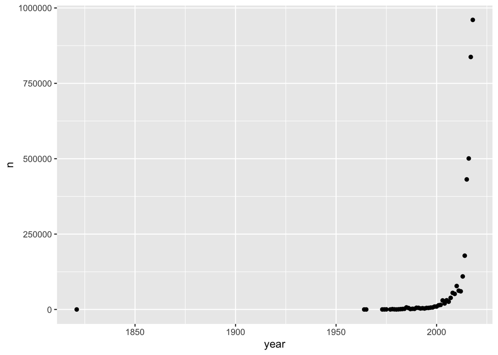

```r
# plot the count above
bird_data_narrower %>%
  count(year) %>%
  ggplot(aes(x = year, y = n)) +
  geom_point()
```

Pelo plot acima, podemos filtrar os dados por ano maior que 1950

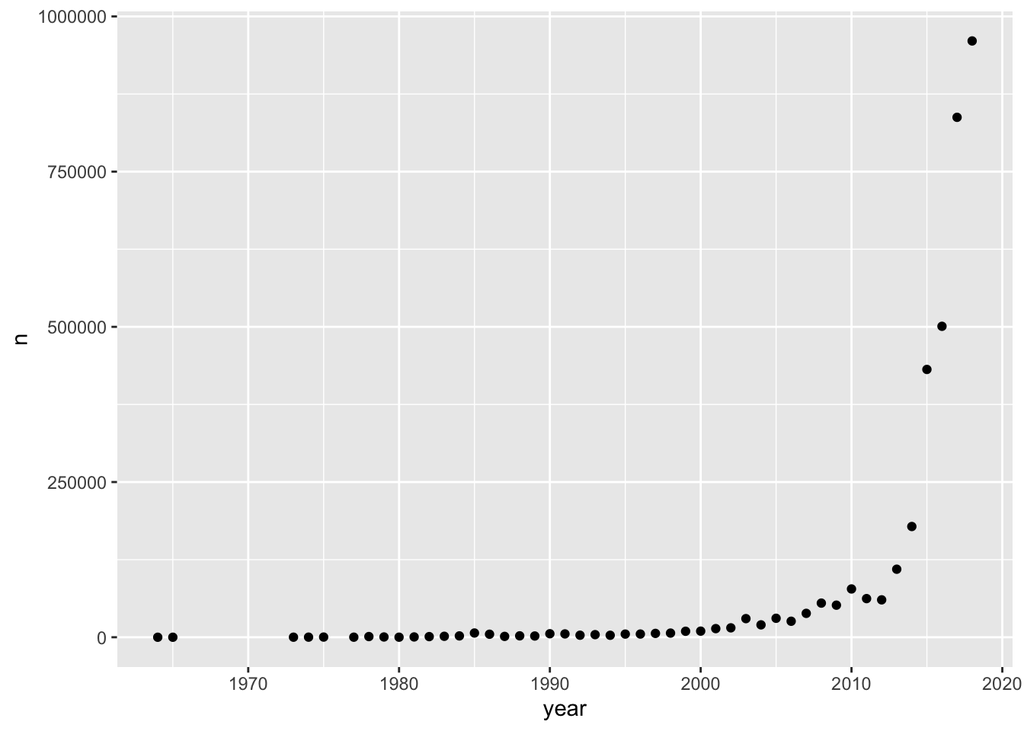

```r
# plot the count above
bird_data_narrower %>%
  filter(year > 1950) %>%
  count(year) %>%
  ggplot(aes(x = year, y = n)) +
  geom_point()
```

E por estado, o que temos?

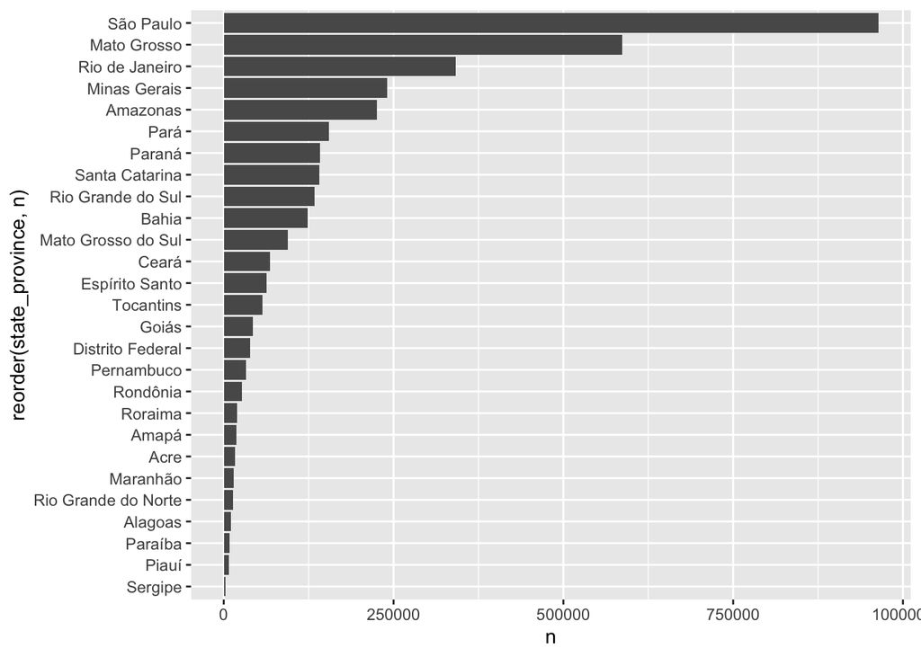

```r
# how many observations per state
bird_data_narrower %>%
  count(state_province) %>%
  ggplot(aes(y = reorder(state_province, n),
             x = n)) +
  geom_col()
```

```r
# save plot in figures folder
ggsave("figures/observations_per_state.png")
```

Looks good.

```r
# how many observations per taxon_rank and verbatim_scientific_name
bird_data_narrower %>%
  distinct(taxon_rank, verbatim_scientific_name) %>%
  count(taxon_rank) %>%
  arrange(-n)
```

```
## # A tibble: 3 x 2
##   taxon_rank     n
##   <chr>      <int>
## 1 SPECIES     1676
## 2 GENUS         10
## 3 FAMILY         1
```

```r
# what's in GENUS?
bird_data_narrower %>%
  filter(taxon_rank == "GENUS") %>%
  count(verbatim_scientific_name)
```

```
## # A tibble: 10 x 2
##    verbatim_scientific_name      n
##    <chr>                     <int>
##  1 Celeus ochraceus           1040
##  2 Dryobates affinis          1947
##  3 Dryobates cassini           537
##  4 Dryobates maculifrons      1181
##  5 Dryobates mixtus            194
##  6 Dryobates passerinus       5593
##  7 Dryobates spilogaster      5470
##  8 Machaeropterus striolatus    13
##  9 Myrmoborus lophotes          58
## 10 Myrmothera subcanescens     418
```

```r
# what's in FAMILY?
bird_data_narrower %>%
  filter(taxon_rank == "FAMILY") %>%
  count(verbatim_scientific_name)
```

```
## # A tibble: 1 x 2
##   verbatim_scientific_name     n
##   <chr>                    <int>
## 1 Oneillornis salvini        170
```

Depois de explorar os dados, decida o que manter.

```r
# save clean/filtered data
bird_data_narrower %>%
  filter(year > 1950) %>%
  write_csv("processed_data/bird_data_clean.csv")
```

## 5.5 Relatório da Análise de Dados (03-data_analysis.Rmd)

Para relatórios, R Markdown permite a integração de prosa e código R no mesmo arquivo. É possível construir relatórios em HTML (como essa página que você está lendo) sem instalar nenhum software ou pacote extra. Para relatórios em pdf, é necessário instalar o pacote `TinyText`.

```r
install.packages("tinytext")
tinytex::install_tinytex()
```

Algumas coisas para considerar. Primeiro, formatação de texto:

```
# A level-one heading
## A level-two heading
### A level-two heading
*italics* or _italics_
**bold** or __bold__
`code`
[link description](http://webaddress.com)
- bullet list item
* bullet list item
1. numbered list item
1. second numbered list item (numbers are incremented automatically in the output)

> A block quote.
>
> > A block quote within a block quote.
```

Você pode acessar a R Markdown Cheat Sheet clicando em `Help` e depois `Cheatsheets`.

Segunda coisa a considerar é `code chunk options`:

- include = FALSE/TRUE: define se os resultados aparecem no documento final. O R Markdown executa o código, independentemente do booleano, e os resultados podem ser usados por outros chunks.
- echo = FALSE/TRUE: define se o código, mas não os resultados, aparecerá no documento final.
- message = FALSE/TRUE: define se as mensagens geradas pelo código aparecem no documento final.
- warning = FALSE/TRUE: define se as mensagens de aviso geradas pelo código aparecem no documento final.

```r
# read in clean/filtered data
bird_data_clear <- read_csv("processed_data/bird_data_clean.csv")
```

# 6 Recursos Extra

Um estilo de programação refere-se a como você nomeia seus objetos e funções, como você comenta seu código, como você usa espaçamento, etc. Se seu estilo de codificação for consistente, seu código será mais fácil de ler e depurar no futuro. Aqui estão alguns guias para que você possa desenvolver seu próprio estilo de codificação:

- [The tidyverse style guide](https://style.tidyverse.org)
- [Hadley Wickham’s Advance R coding style](http://adv-r.had.co.nz/Style.html)
- [Google’s R Style Guide](https://google.github.io/styleguide/Rguide.html)

Meu livro favorito de R para ciência de dados é gratuíto e está disponível online:

- [R for Data Science](https://r4ds.had.co.nz/)